# 2 Module 2: Class 1

Today we will:

- Introduce the Law of Large Numbers (LLN)
- We will use simulations to demonstrate the LLN
  - Simulations -> Math
  - Math -> Simulations
  - Then we will create a simulation where the LLN doesn’t work

## 2.1 Conceptual overview

This is to illustrate the law of large numbers using some example data.

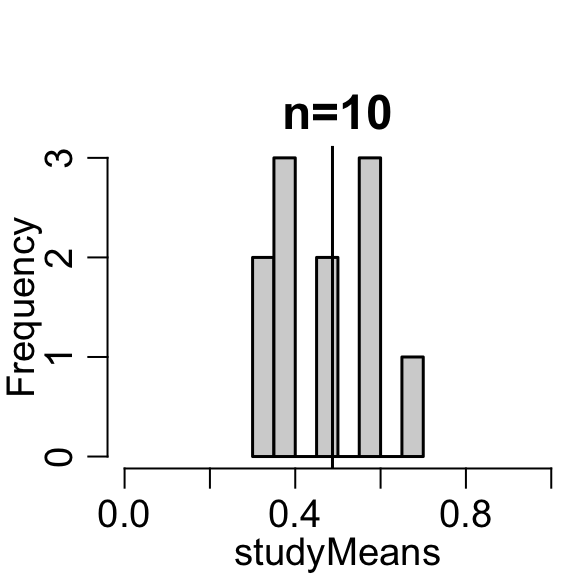

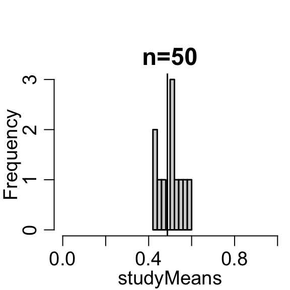

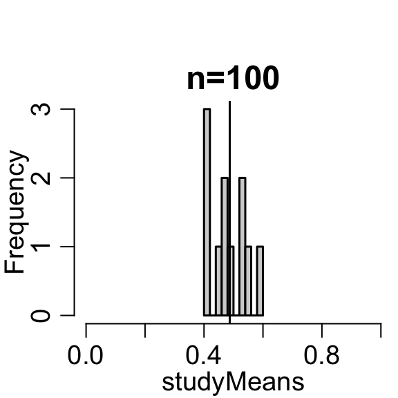

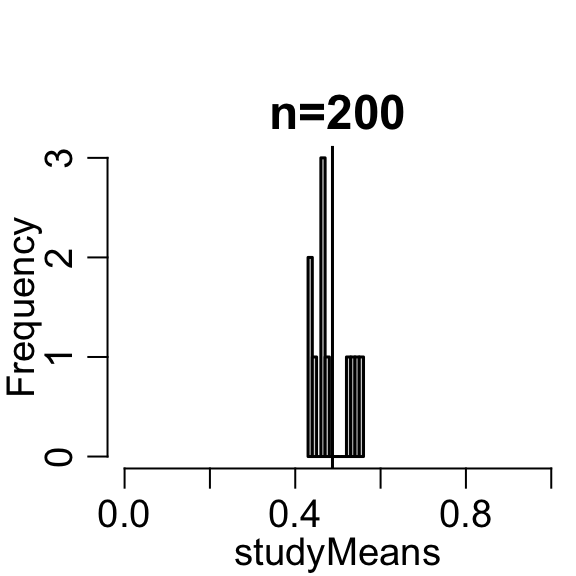

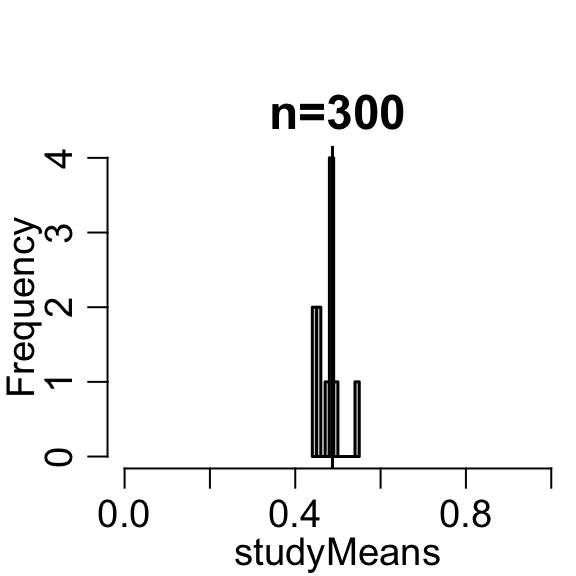

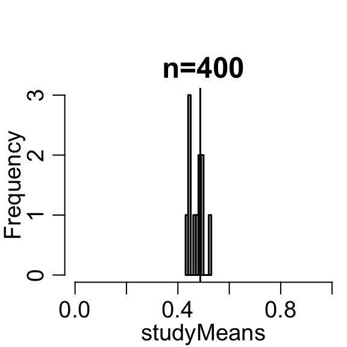

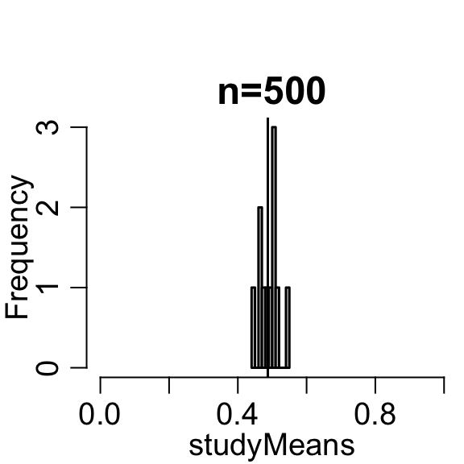

```r
# read in student names
# each student is a researcher
students = read.csv('../../unshared/students2023.csv')

# read in data
puf = readRDS('../datasets/nsduh/puf.rds')
# ever tried cigarettes indicator
triedCigs = puf$cigflag
# make it a Bernoulli random variable
triedCigs = ifelse(triedCigs=='yes', 1, 0)

ns = c(10, 50, 100, 200, 300, 400, 500)

for(n in ns){
  # Each person in the class is performing a study of smoking
  studies = lapply(students$First.Name, function(student) sample(triedCigs, size=n))
  names(studies) = students$First.Name

  # get the mean for each person's study
  studyMeans = sapply(studies, mean)
  # histogram of the study means
  hist(studyMeans, xlim=c(0,1), breaks=10, main=paste0('n=', n))
  abline(v=mean(triedCigs))
}
```

```r
#hist(sqrt(n)*(studyMeans-mean(triedCigs)), xlim=c(0,1), breaks=10, main=paste0('n=', n))
```

## 2.2 Law of Large Numbers overview

- The LLN is a tool we can use to say that the average of a sample is close to its expected value (and get’s closer with larger sample sizes).
- I wouldn’t consider an estimator that doesn’t satisfy the LLN

## 2.3 Simulations -> Math: illustrating the LLN with simulations

### 2.3.1 Initial simulation without convergence definition

- First, let’s choose a distribution (together as a class).
- Then, let’s initialize empty vectors, `x` and `means`.
- For `n in 1:maxn`,
  - Draw a sample from our distribution and add it to `x`, `x<-c(x,<new random sample>)`.
  - Compute the mean of `x` and save it in another vector `means[n]<- mean(x)`.
- Plot the vector `means`.

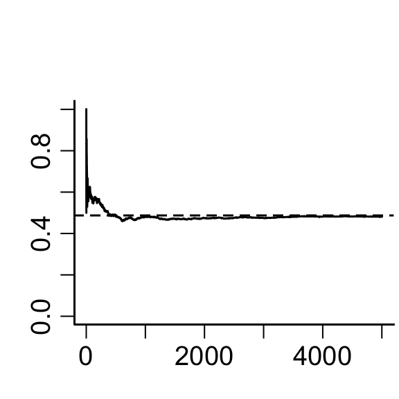

```r
# distribution we're sampling from
p = mean(triedCigs)
RVfunc = function(n) rbinom(n, size=1, prob=p)
# x is the observed sample
x = c()
# this is the mean of the observed sample
means = c()
# maximum sample size to get to
maxn=5000

# for loop through samples
for(n in 1:maxn){
  xn = RVfunc(1)
  x = c(x, xn)
  means = c(means, mean(x))
  }



plot(1:maxn, means, type='l', xlab='', ylab='', ylim=c(0,1))
# what is this converging to?
abline(h=p, lty=2)
```

What do you notice about this plot?

Let’s describe mathematically what we did.

- $X_i \sim$, for $n=1,2, \ldots$
- $\bar X_n = \frac{1}{n} \sum_{i=1}^n X_i$
- $\bar X_n \to$ what? What does this little arrow mean?

### 2.3.2 Convergence of random variables

**Definition:** $Y_n$ converges to $Y$ *in probability* if for all $\epsilon>0$, $\lim_{n\to\infty}\mathbb{P}(\lvert Y_n - Y \rvert \le \epsilon) = 1$ as $n\to\infty$.

**Definition:** $Y_n$ converges *almost surely* to $Y$ if $\mathbb{P}(\lim_{n\to \infty}\lvert Y_n - Y \rvert =0) = 1$ as $n\to\infty$.

## 2.4 Math -> Simulations: adding convergence definition

How do we incorporate one of these convergence definitions into our simulations?

```r
epsilon = 0.02
nsim = 500
# distribution we're sampling from
p = mean(triedCigs)
RVfunc = function(n) rbinom(n, size=1, prob=p)
# maximum sample size to get to
maxn=10000
# this is the mean of the observed sample
meansout = matrix(NA, nrow=nsim, ncol=maxn)


for(sim in 1:nsim){
  cat(sim, '\t')
  # for loop through samples
  # x is the observed sample
  x = c()
  means = c()

  x = RVfunc(maxn)
  meansout[sim,] = cumsum(x)/1:maxn
  # for(n in 1:maxn){
  #   xn = RVfunc(1)
  #   x = c(x, xn)
  #   means = c(means, mean(x))
  # }
  # meansout[sim,] = means
}
```

[output not shown]

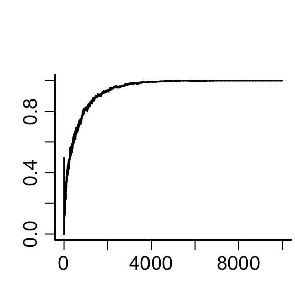

```r
P_XbarMinusp = colMeans(abs(meansout - p) < epsilon)

plot(1:maxn, P_XbarMinusp, type='l', xlab='', ylab='', ylim=c(0,1))
```

```r
# plot(1:maxn, means, type='l', xlab='', ylab='')
# what is this converging to?
# abline(h=, lty=2)
```